# A TensorFlow笔记5 使用GoogLeNet做技术分析的模式识别-2018-4-4 16:31:55

### 使用tensorflow构建GoogLeNet构建技术分析因子的模式识别

### 今天偶然看到RiceQuant支持tensorflow，就把之前写的一个帖子搬到线上了。

```python
import matplotlib.image as mpimg
```

### NiN结构的Inception module, GoogleLeNet核心卷积模块，一个拓宽宽度的滤波器 ,相当于一个高度非线性的滤波器

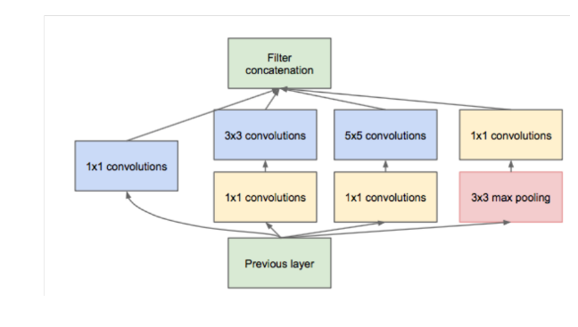

```python
image = mpimg.imread("jpb.png")
plt.figure(figsize=(14,6))
plt.axis("off")
plt.imshow(image)
plt.show()
```

### GoogleLeNet 拓扑结构图，可以看到GoogleLeNet在LeNet网络结构上面大量使用Inception_unit滤波器拓宽加深LeNet网络，Going deeper with convolutions论文中Inception_unit滤波器将稀疏矩阵合并成稠密矩阵的方法和路径具有相当的工程价值

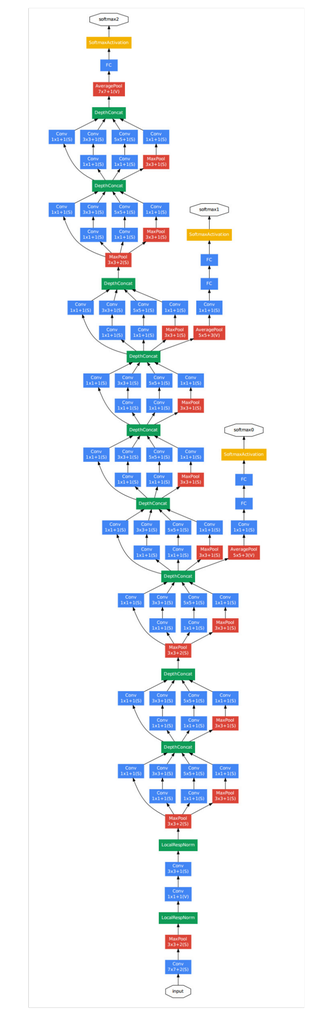

```python
image = mpimg.imread("jpa.png")
plt.figure(figsize=(16,46))
plt.axis("off")
plt.imshow(image)
plt.show()
```

```python
import numpy as np
import pandas as pd
import tensorflow as tf
import Technical_Analysis_Factor_Package_Library as TAF
import datetime
import matplotlib.pylab as plt
#import seaborn as sns
% matplotlib inline

HS300 = pd.read_csv('HS300.csv')
HS300.rename(columns={'Unnamed: 0':'tradingPeriod', 'TotalVolumeTraded':'turnoverVol',
                     'HighPx':'highestPrice', 'OpeningPx':'openPrice','TotalTurnover':'turnoverValue',
                     'LowPx':'lowestPrice', 'ClosingPx':'closePrice'}, inplace= True)
HS300 = TAF.Technical_Analysis_Factor_Normalization(inputdata= HS300, rolling=16*40, Tdropna= True)

Dtmp = pd.read_csv('HS300D.csv')
Dtmp.rename(columns={'Unnamed: 0':'tradingPeriod', 'TotalVolumeTraded':'turnoverVol',
                     'HighPx':'highestPrice', 'OpeningPx':'openPrice','TotalTurnover':'turnoverValue',
                     'LowPx':'lowestPrice', 'ClosingPx':'closePrice'}, inplace= True)

# 预测14天涨跌
Dtmp['actual_future_rate_of_return'] = Dtmp.closePrice.shift(-14)/Dtmp.closePrice - 1.0
Dtmp = Dtmp.dropna()
Dtmp = Dtmp[-200:]
Dtmp['Direction_Label'] = 0
Dtmp.actual_future_rate_of_return.describe()
Dtmp.loc[Dtmp.actual_future_rate_of_return>0.025,'Direction_Label'] = 1
Dtmp.loc[Dtmp.actual_future_rate_of_return<-0.01,'Direction_Label'] = -1
Dtmp.reset_index(drop= True , inplace= True)

start = Dtmp.tradingPeriod.values[0]
end = Dtmp.tradingPeriod.values[-1]
end = datetime.datetime.strptime(end,'%Y-%m-%d') # 将STR转换为datetime
end = end + datetime.timedelta(days=1) # 增加一天
end = end.strftime('%Y-%m-%d')

fac_HS300 = HS300.ix[(HS300.tradingPeriod.values>start) & (HS300.tradingPeriod.values<end)].reset_index(drop=True)
fac_list = TAF.get_Multifactor_list(fac_HS300)
fac_list = fac_list[:56]

fe = 56 # 回溯日期
tmp_HS300 = np.zeros((1,fe*16*56))
for i in np.arange(fe,int(len(fac_HS300)/16)):
    tmp = fac_HS300.ix[16*(i-fe):16*i-1][fac_list]
    tmp = np.array(tmp).ravel(order='C').transpose()
    tmp_HS300 = np.vstack((tmp_HS300,tmp))
tmp_HS300 = np.delete(tmp_HS300,0,axis=0)
```

```
Number of data losses 726 Ratio : 0.0467302
```

### GoogLeNet用于图像识别，如果我们将技术分析因子投影到0~255范围内合成图像，则可以强假设技术分析因子合成图片使用图片分类进行涨跌预测。

- 技术分析因子数值波动

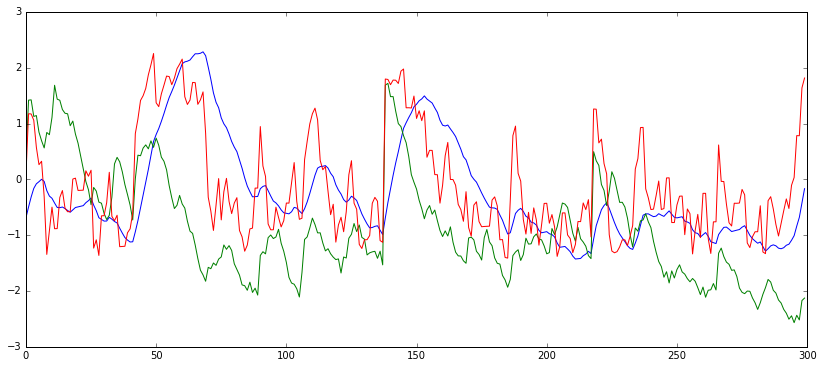

```python
o = HS300.ATR14[:300]
p = HS300.ADX[:300]
q = HS300.DX[:300]
fig = plt.figure(figsize=(14,6))
plt.plot(p)
plt.plot(o)
plt.plot(q)
```

- 多种技术分析因子数值在Y轴并列之后使用颜色表示因子数值大小

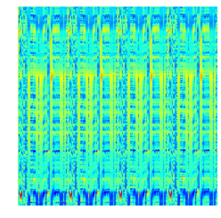

```python
import matplotlib.pyplot as plt
import matplotlib.image as mping
plt.figure(figsize=(6,6))
shpig = tmp_HS300[1]
shpig = shpig.reshape(224,224)
shpig +=4
shpig *=26
plt.axis("off")
plt.imshow(shpig)
plt.show()
```

### 数据读取部分，我这个模型是在本地建立的，懒得改代码了就直接把数据上传到平台上面了

```python
HS300 = pd.read_csv('HS300.csv')
SHCI  = pd.read_csv('SHCI.csv')
ZZ500  = pd.read_csv('ZZ500.csv')
CYBZ  = pd.read_csv('CYBZ.csv')
HS300.rename(columns={'Unnamed: 0':'tradingPeriod', 'TotalVolumeTraded':'turnoverVol',
                     'HighPx':'highestPrice', 'OpeningPx':'openPrice','TotalTurnover':'turnoverValue',
                     'LowPx':'lowestPrice', 'ClosingPx':'closePrice'}, inplace= True)
HS300 = TAF.Technical_Analysis_Factor_Normalization(inputdata= HS300, rolling=16*40, Tdropna= True)

SHCI.rename(columns={'Unnamed: 0':'tradingPeriod', 'TotalVolumeTraded':'turnoverVol',
                     'HighPx':'highestPrice', 'OpeningPx':'openPrice','TotalTurnover':'turnoverValue',
                     'LowPx':'lowestPrice', 'ClosingPx':'closePrice'}, inplace= True)
SHCI = TAF.Technical_Analysis_Factor_Normalization(inputdata= SHCI, rolling=16*40, Tdropna= True)

ZZ500.rename(columns={'Unnamed: 0':'tradingPeriod', 'TotalVolumeTraded':'turnoverVol',
                     'HighPx':'highestPrice', 'OpeningPx':'openPrice','TotalTurnover':'turnoverValue',
                     'LowPx':'lowestPrice', 'ClosingPx':'closePrice'}, inplace= True)
ZZ500 = TAF.Technical_Analysis_Factor_Normalization(inputdata= ZZ500, rolling=16*40, Tdropna= True)

CYBZ.rename(columns={'Unnamed: 0':'tradingPeriod', 'TotalVolumeTraded':'turnoverVol',
                     'HighPx':'highestPrice', 'OpeningPx':'openPrice','TotalTurnover':'turnoverValue',
                     'LowPx':'lowestPrice', 'ClosingPx':'closePrice'}, inplace= True)
CYBZ = TAF.Technical_Analysis_Factor_Normalization(inputdata= CYBZ, rolling=16*40, Tdropna= True)

Dtmp = pd.read_csv('HS300D.csv')
Dtmp.rename(columns={'Unnamed: 0':'tradingPeriod', 'TotalVolumeTraded':'turnoverVol',
                     'HighPx':'highestPrice', 'OpeningPx':'openPrice','TotalTurnover':'turnoverValue',
                     'LowPx':'lowestPrice', 'ClosingPx':'closePrice'}, inplace= True)
# 预测14天涨跌
Dtmp['actual_future_rate_of_return'] = Dtmp.closePrice.shift(-14)/Dtmp.closePrice - 1.0
Dtmp = Dtmp.dropna()
Dtmp = Dtmp[-200:]
Dtmp['Direction_Label'] = 0
Dtmp.actual_future_rate_of_return.describe()
Dtmp.loc[Dtmp.actual_future_rate_of_return>0.025,'Direction_Label'] = 1
Dtmp.loc[Dtmp.actual_future_rate_of_return<-0.01,'Direction_Label'] = -1
Dtmp.reset_index(drop= True , inplace= True)

start = Dtmp.tradingPeriod.values[0]
end = Dtmp.tradingPeriod.values[-1]
end = datetime.datetime.strptime(end,'%Y-%m-%d') # 将STR转换为datetime
end = end + datetime.timedelta(days=1) # 增加一天
end = end.strftime('%Y-%m-%d')

fac_HS300 = HS300.ix[(HS300.tradingPeriod.values>start) & (HS300.tradingPeriod.values<end)].reset_index(drop=True)
fac_ZZ500 = HS300.ix[(ZZ500.tradingPeriod.values>start) & (ZZ500.tradingPeriod.values<end)].reset_index(drop=True)
fac_SHCI = HS300.ix[(SHCI.tradingPeriod.values>start) & (SHCI.tradingPeriod.values<end)].reset_index(drop=True)
fac_CYBZ = HS300.ix[(CYBZ.tradingPeriod.values>start) & (CYBZ.tradingPeriod.values<end)].reset_index(drop=True)
fac_list = TAF.get_Multifactor_list(fac_HS300)
fac_list = fac_list[:56]

def overs(fac_HS300):
    fe = 56 # 回溯日期
    tmp_HS300 = np.zeros((1,fe*16*56))
    for i in np.arange(fe,1+int(len(fac_HS300)/16)):
        tmp = fac_HS300.ix[16*(i-fe):16*i-1][fac_list]
        tmp = np.array(tmp).ravel(order='C').transpose()
        tmp_HS300 = np.vstack((tmp_HS300,tmp))
    tmp_HS300 = np.delete(tmp_HS300,0,axis=0)
    return tmp_HS300

fac_HS300 = overs(fac_HS300)
fac_CYBZ = overs(fac_CYBZ)
fac_SHCI = overs(fac_SHCI)
fac_ZZ500 = overs(fac_ZZ500)

fac_HS300 = fac_HS300.reshape(145,50176)
fac = np.array(fac_HS300)

ret = Dtmp.iloc[-145:,-1]
ret = np.array(ret)
wid = np.zeros((145,3))
wid[np.arange(145),ret] = 1
ret = wid
```

```
Number of data losses 726 Ratio : 0.0467302
Number of data losses 726 Ratio : 0.0467302
Number of data losses 726 Ratio : 0.0467302
Number of data losses 726 Ratio : 0.0467302
```

### GoogLeNet 拓扑结构构建部分

```python
def inception_unit(inception_in, weights, biases):

    # Conv 1x1+S1
    inception_1x1_S1 = tf.nn.conv2d(inception_in, weights['inception_1x1_S1'], strides=[1,1,1,1], padding='SAME')
    inception_1x1_S1 = tf.nn.bias_add(inception_1x1_S1, biases['inception_1x1_S1'])
    inception_1x1_S1 = tf.nn.relu(inception_1x1_S1)
    # Conv 3x3+S1
    inception_3x3_S1_reduce = tf.nn.conv2d(inception_in, weights['inception_3x3_S1_reduce'], strides=[1,1,1,1], padding='SAME')
    inception_3x3_S1_reduce = tf.nn.bias_add(inception_3x3_S1_reduce, biases['inception_3x3_S1_reduce'])
    inception_3x3_S1_reduce = tf.nn.relu(inception_3x3_S1_reduce)
    inception_3x3_S1 = tf.nn.conv2d(inception_3x3_S1_reduce, weights['inception_3x3_S1'], strides=[1,1,1,1], padding='SAME')
    inception_3x3_S1 = tf.nn.bias_add(inception_3x3_S1, biases['inception_3x3_S1'])
    inception_3x3_S1 = tf.nn.relu(inception_3x3_S1)
    # Conv 5x5+S1
    inception_5x5_S1_reduce = tf.nn.conv2d(inception_in, weights['inception_5x5_S1_reduce'], strides=[1,1,1,1], padding='SAME')
    inception_5x5_S1_reduce = tf.nn.bias_add(inception_5x5_S1_reduce, biases['inception_5x5_S1_reduce'])
    inception_5x5_S1_reduce = tf.nn.relu(inception_5x5_S1_reduce)
    inception_5x5_S1 = tf.nn.conv2d(inception_5x5_S1_reduce, weights['inception_5x5_S1'], strides=[1,1,1,1], padding='SAME')
    inception_5x5_S1 = tf.nn.bias_add(inception_5x5_S1, biases['inception_5x5_S1'])
    inception_5x5_S1 = tf.nn.relu(inception_5x5_S1)
    # MaxPool
    inception_MaxPool = tf.nn.max_pool(inception_in, ksize=[1,3,3,1], strides=[1,1,1,1], padding='SAME')
    inception_MaxPool = tf.nn.conv2d(inception_MaxPool, weights['inception_MaxPool'], strides=[1,1,1,1], padding='SAME')
    inception_MaxPool = tf.nn.bias_add(inception_MaxPool, biases['inception_MaxPool'])
    inception_MaxPool = tf.nn.relu(inception_MaxPool)
    # Concat
    #tf.concat(concat_dim, values, name='concat')
    #concat_dim是tensor连接的方向（维度），values是要连接的tensor链表，name是操作名。cancat_dim维度可以不一样，其他维度的尺寸必须一样。
    inception_out = tf.concat(concat_dim=3, values=[inception_1x1_S1, inception_3x3_S1, inception_5x5_S1, inception_MaxPool])
    return inception_out

weights = {
    'conv1_7x7_S2': tf.Variable(tf.random_normal([7,7,1,64])),
    'conv2_1x1_S1': tf.Variable(tf.random_normal([1,1,64,64])),
    'conv2_3x3_S1': tf.Variable(tf.random_normal([3,3,64,192])),
    'FC2': tf.Variable(tf.random_normal([7*7*832, 3])),
    'test': tf.Variable(tf.random_normal([7*7*1024,3]))

}

biases = {
    'conv1_7x7_S2': tf.Variable(tf.random_normal([64])),
    'conv2_1x1_S1': tf.Variable(tf.random_normal([64])),
    'conv2_3x3_S1': tf.Variable(tf.random_normal([192])),
    'FC2': tf.Variable(tf.random_normal([3])),
    'test': tf.Variable(tf.random_normal([3]))

}


conv_W_3a = {
    'inception_1x1_S1': tf.Variable(tf.random_normal([1,1,192,64])),
    'inception_3x3_S1_reduce': tf.Variable(tf.random_normal([1,1,192,96])),
    'inception_3x3_S1': tf.Variable(tf.random_normal([1,1,96,128])),
    'inception_5x5_S1_reduce': tf.Variable(tf.random_normal([1,1,192,16])),
    'inception_5x5_S1': tf.Variable(tf.random_normal([5,5,16,32])),
    'inception_MaxPool': tf.Variable(tf.random_normal([1,1,192,32]))

}

conv_B_3a = {
    'inception_1x1_S1': tf.Variable(tf.random_normal([64])),
    'inception_3x3_S1_reduce': tf.Variable(tf.random_normal([96])),
    'inception_3x3_S1': tf.Variable(tf.random_normal([128])),
    'inception_5x5_S1_reduce': tf.Variable(tf.random_normal([16])),
    'inception_5x5_S1': tf.Variable(tf.random_normal([32])),
    'inception_MaxPool': tf.Variable(tf.random_normal([32]))
}

conv_W_3b = {
    'inception_1x1_S1': tf.Variable(tf.random_normal([1,1,256,128])),
    'inception_3x3_S1_reduce': tf.Variable(tf.random_normal([1,1,256,128])),
    'inception_3x3_S1': tf.Variable(tf.random_normal([1,1,128,192])),
    'inception_5x5_S1_reduce': tf.Variable(tf.random_normal([1,1,256,32])),
    'inception_5x5_S1': tf.Variable(tf.random_normal([5,5,32,96])),
    'inception_MaxPool': tf.Variable(tf.random_normal([1,1,256,64]))

}

conv_B_3b = {
    'inception_1x1_S1': tf.Variable(tf.random_normal([128])),
    'inception_3x3_S1_reduce': tf.Variable(tf.random_normal([128])),
    'inception_3x3_S1': tf.Variable(tf.random_normal([192])),
    'inception_5x5_S1_reduce': tf.Variable(tf.random_normal([32])),
    'inception_5x5_S1': tf.Variable(tf.random_normal([96])),
    'inception_MaxPool': tf.Variable(tf.random_normal([64]))
}

conv_W_4a = {
    'inception_1x1_S1': tf.Variable(tf.random_normal([1,1,480,192])),
    'inception_3x3_S1_reduce': tf.Variable(tf.random_normal([1,1,480,96])),
    'inception_3x3_S1': tf.Variable(tf.random_normal([1,1,96,208])),
    'inception_5x5_S1_reduce': tf.Variable(tf.random_normal([1,1,480,16])),
    'inception_5x5_S1': tf.Variable(tf.random_normal([5,5,16,48])),
    'inception_MaxPool': tf.Variable(tf.random_normal([1,1,480,64]))

}

conv_B_4a = {
    'inception_1x1_S1': tf.Variable(tf.random_normal([192])),
    'inception_3x3_S1_reduce': tf.Variable(tf.random_normal([96])),
    'inception_3x3_S1': tf.Variable(tf.random_normal([208])),
    'inception_5x5_S1_reduce': tf.Variable(tf.random_normal([16])),
    'inception_5x5_S1': tf.Variable(tf.random_normal([48])),
    'inception_MaxPool': tf.Variable(tf.random_normal([64]))
}


conv_W_4b = {
    'inception_1x1_S1': tf.Variable(tf.random_normal([1,1,512,160])),
    'inception_3x3_S1_reduce': tf.Variable(tf.random_normal([1,1,512,112])),
    'inception_3x3_S1': tf.Variable(tf.random_normal([1,1,112,224])),
    'inception_5x5_S1_reduce': tf.Variable(tf.random_normal([1,1,512,24])),
    'inception_5x5_S1': tf.Variable(tf.random_normal([5,5,24,64])),
    'inception_MaxPool': tf.Variable(tf.random_normal([1,1,512,64]))

}

conv_B_4b = {
    'inception_1x1_S1': tf.Variable(tf.random_normal([160])),
    'inception_3x3_S1_reduce': tf.Variable(tf.random_normal([112])),
    'inception_3x3_S1': tf.Variable(tf.random_normal([224])),
    'inception_5x5_S1_reduce': tf.Variable(tf.random_normal([24])),
    'inception_5x5_S1': tf.Variable(tf.random_normal([64])),
    'inception_MaxPool': tf.Variable(tf.random_normal([64]))
}
```

```python
conv_W_4c = {
    'inception_1x1_S1': tf.Variable(tf.random_normal([1,1,512,128])),
    'inception_3x3_S1_reduce': tf.Variable(tf.random_normal([1,1,512,128])),
    'inception_3x3_S1': tf.Variable(tf.random_normal([1,1,128,256])),
    'inception_5x5_S1_reduce': tf.Variable(tf.random_normal([1,1,512,24])),
    'inception_5x5_S1': tf.Variable(tf.random_normal([5,5,24,64])),
    'inception_MaxPool': tf.Variable(tf.random_normal([1,1,512,64]))

}

conv_B_4c = {
    'inception_1x1_S1': tf.Variable(tf.random_normal([128])),
    'inception_3x3_S1_reduce': tf.Variable(tf.random_normal([128])),
    'inception_3x3_S1': tf.Variable(tf.random_normal([256])),
    'inception_5x5_S1_reduce': tf.Variable(tf.random_normal([24])),
    'inception_5x5_S1': tf.Variable(tf.random_normal([64])),
    'inception_MaxPool': tf.Variable(tf.random_normal([64]))
}

conv_W_4d = {
    'inception_1x1_S1': tf.Variable(tf.random_normal([1,1,512,112])),
    'inception_3x3_S1_reduce': tf.Variable(tf.random_normal([1,1,512,144])),
    'inception_3x3_S1': tf.Variable(tf.random_normal([1,1,144,288])),
    'inception_5x5_S1_reduce': tf.Variable(tf.random_normal([1,1,512,32])),
    'inception_5x5_S1': tf.Variable(tf.random_normal([5,5,32,64])),
    'inception_MaxPool': tf.Variable(tf.random_normal([1,1,512,64]))

}

conv_B_4d = {
    'inception_1x1_S1': tf.Variable(tf.random_normal([112])),
    'inception_3x3_S1_reduce': tf.Variable(tf.random_normal([144])),
    'inception_3x3_S1': tf.Variable(tf.random_normal([288])),
    'inception_5x5_S1_reduce': tf.Variable(tf.random_normal([32])),
    'inception_5x5_S1': tf.Variable(tf.random_normal([64])),
    'inception_MaxPool': tf.Variable(tf.random_normal([64]))
}

conv_W_4e = {
    'inception_1x1_S1': tf.Variable(tf.random_normal([1,1,528,256])),
    'inception_3x3_S1_reduce': tf.Variable(tf.random_normal([1,1,528,160])),
    'inception_3x3_S1': tf.Variable(tf.random_normal([1,1,160,320])),
    'inception_5x5_S1_reduce': tf.Variable(tf.random_normal([1,1,528,32])),
    'inception_5x5_S1': tf.Variable(tf.random_normal([5,5,32,128])),
    'inception_MaxPool': tf.Variable(tf.random_normal([1,1,528,128]))

}

conv_B_4e = {
    'inception_1x1_S1': tf.Variable(tf.random_normal([256])),
    'inception_3x3_S1_reduce': tf.Variable(tf.random_normal([160])),
    'inception_3x3_S1': tf.Variable(tf.random_normal([320])),
    'inception_5x5_S1_reduce': tf.Variable(tf.random_normal([32])),
    'inception_5x5_S1': tf.Variable(tf.random_normal([128])),
    'inception_MaxPool': tf.Variable(tf.random_normal([128]))
}

conv_W_5a = {
    'inception_1x1_S1': tf.Variable(tf.random_normal([1,1,832,256])),
    'inception_3x3_S1_reduce': tf.Variable(tf.random_normal([1,1,832,160])),
    'inception_3x3_S1': tf.Variable(tf.random_normal([1,1,160,320])),
    'inception_5x5_S1_reduce': tf.Variable(tf.random_normal([1,1,832,32])),
    'inception_5x5_S1': tf.Variable(tf.random_normal([5,5,32,128])),
    'inception_MaxPool': tf.Variable(tf.random_normal([1,1,832,128]))

}

conv_B_5a = {
    'inception_1x1_S1': tf.Variable(tf.random_normal([256])),
    'inception_3x3_S1_reduce': tf.Variable(tf.random_normal([160])),
    'inception_3x3_S1': tf.Variable(tf.random_normal([320])),
    'inception_5x5_S1_reduce': tf.Variable(tf.random_normal([32])),
    'inception_5x5_S1': tf.Variable(tf.random_normal([128])),
    'inception_MaxPool': tf.Variable(tf.random_normal([128]))
}

conv_W_5b = {
    'inception_1x1_S1': tf.Variable(tf.random_normal([1,1,832,384])),
    'inception_3x3_S1_reduce': tf.Variable(tf.random_normal([1,1,832,192])),
    'inception_3x3_S1': tf.Variable(tf.random_normal([1,1,192,384])),
    'inception_5x5_S1_reduce': tf.Variable(tf.random_normal([1,1,832,48])),
    'inception_5x5_S1': tf.Variable(tf.random_normal([5,5,48,128])),
    'inception_MaxPool': tf.Variable(tf.random_normal([1,1,832,128]))

}

conv_B_5b = {
    'inception_1x1_S1': tf.Variable(tf.random_normal([384])),
    'inception_3x3_S1_reduce': tf.Variable(tf.random_normal([192])),
    'inception_3x3_S1': tf.Variable(tf.random_normal([384])),
    'inception_5x5_S1_reduce': tf.Variable(tf.random_normal([48])),
    'inception_5x5_S1': tf.Variable(tf.random_normal([128])),
    'inception_MaxPool': tf.Variable(tf.random_normal([128]))
}

softmax0_W = {
    'Conv': tf.Variable(tf.random_normal([1,1,512,128])),
    'FC1' : tf.Variable(tf.random_normal([4*4*128,1024])),
    'FC2' : tf.Variable(tf.random_normal([1024,3]))
}

softmax0_b ={
    'Conv': tf.Variable(tf.random_normal([128])),
    'FC1' : tf.Variable(tf.random_normal([1024])),
    'FC2' : tf.Variable(tf.random_normal([3]))
}

softmax1_W = {
    'Conv': tf.Variable(tf.random_normal([1,1,528,128]),name='Stest'),
    'FC1' : tf.Variable(tf.random_normal([4*4*128,1024])),
    'FC2' : tf.Variable(tf.random_normal([1024,3]))
}

softmax1_b ={
    'Conv': tf.Variable(tf.random_normal([128])),
    'FC1' : tf.Variable(tf.random_normal([1024])),
    'FC2' : tf.Variable(tf.random_normal([3]))
}


def GoogLeNet_C1(x, weights, bias, conv_W_3a, conv_B_3a, conv_W_3b,conv_B_3b,conv_W_4a,conv_B_4a,conv_W_4b,
                                      conv_B_4b,conv_W_4c,conv_B_4c,conv_W_4d,conv_B_4d,conv_W_4e,conv_B_4e,conv_W_5a,conv_B_5a,
                                      conv_W_5b,conv_B_5b, softmax0_W ,softmax0_b, softmax1_W ,softmax1_b, dropout=0.8):
    x = tf.reshape(x, shape=[-1,224,224,1])

    # layer 1
    x = tf.nn.conv2d(x, weights['conv1_7x7_S2'], strides= [1,2,2,1], padding='SAME')
    x = tf.nn.bias_add(x, bias['conv1_7x7_S2'])
    x = tf.nn.relu(x)
    x = tf.nn.max_pool(x, ksize=[1,3,3,1], strides=[1,2,2,1], padding='SAME')
    x = tf.nn.local_response_normalization(x, depth_radius=5/2.0, bias=2.0, alpha=1e-4, beta= 0.75)

    # layer 2
    x = tf.nn.conv2d(x, weights['conv2_1x1_S1'], strides=[1,1,1,1], padding='SAME')
    x = tf.nn.bias_add(x, biases['conv2_1x1_S1'])
    x = tf.nn.relu(x)
    x = tf.nn.conv2d(x, weights['conv2_3x3_S1'], strides=[1,1,1,1], padding='SAME')
    x = tf.nn.bias_add(x, biases['conv2_3x3_S1'])
    x = tf.nn.relu(x)
    x = tf.nn.local_response_normalization(x, depth_radius=5/2.0, bias=2.0, alpha=1e-4, beta= 0.75)
    x = tf.nn.max_pool(x, ksize=[1,3,3,1], strides=[1,2,2,1], padding='SAME')
```

```python
    # layer 3
    inception_3a = inception_unit(inception_in=x, weights=conv_W_3a, biases=conv_B_3a)
    inception_3b = inception_unit(inception_3a, weights=conv_W_3b, biases=conv_B_3b)

    # 池化层
    x = inception_3b
    x = tf.nn.max_pool(x, ksize=[1,3,3,1], strides=[1,2,2,1], padding='SAME' )

    # inception 4
    inception_4a = inception_unit(inception_in=x, weights=conv_W_4a, biases=conv_B_4a)
    # 引出第一条分支
    softmax0 = inception_4a
    inception_4b = inception_unit(inception_4a, weights=conv_W_4b, biases=conv_B_4b)
    inception_4c = inception_unit(inception_4b, weights=conv_W_4c, biases=conv_B_4c)
    inception_4d = inception_unit(inception_4c, weights=conv_W_4d, biases=conv_B_4d)
    # 引出第二条分支
    softmax1 = inception_4d
    inception_4e = inception_unit(inception_4d, weights=conv_W_4e, biases=conv_B_4e)

    # 池化
    x = inception_4e
    x = tf.nn.max_pool(x, ksize=[1,3,3,1], strides=[1,2,2,1], padding='SAME' )

    # inception 5
    x = inception_unit(x, weights=conv_W_5a, biases=conv_B_5a)
    inception_5b = inception_unit(x, weights=conv_W_5a, biases=conv_B_5a)
    #print (inception_5b.get_shape().as_list())


    # softmax 0
    softmax0 = tf.nn.avg_pool(softmax0, ksize=[1,5,5,1], strides=[1,3,3,1], padding='VALID')
    softmax1 = tf.nn.avg_pool(softmax1, ksize=[1,5,5,1], strides=[1,3,3,1], padding='VALID')
    softmax2 = tf.nn.avg_pool(inception_5b, ksize=[1,7,7,1], strides=[1,1,1,1], padding='SAME')
    #print (softmax2.get_shape().as_list())


    softmax0 = tf.nn.conv2d(softmax0, softmax0_W['Conv'], strides=[1,1,1,1], padding='SAME')
    softmax0 = tf.nn.bias_add(softmax0, softmax0_b['Conv'])
    softmax0 = tf.nn.relu(softmax0)

    softmax0 = tf.reshape(softmax0, [-1,softmax0_W['FC1'].get_shape().as_list()[0]])
    softmax0 = tf.add(tf.matmul(softmax0, softmax0_W['FC1']), softmax0_b['FC1'])
    softmax0 = tf.nn.relu(softmax0)

    softmax0 = tf.nn.dropout(softmax0,keep_prob= 0.3)

    softmax0 = tf.reshape(softmax0, [-1,softmax0_W['FC2'].get_shape().as_list()[0]])
    softmax0 = tf.add(tf.matmul(softmax0, softmax0_W['FC2']), softmax0_b['FC2'])


    # softmax1
    softmax1 = tf.nn.conv2d(softmax1, softmax1_W['Conv'], strides=[1,1,1,1], padding='SAME')
    softmax1 = tf.nn.bias_add(softmax1, softmax1_b['Conv'])
    softmax1 = tf.nn.relu(softmax1)

    softmax1 = tf.reshape(softmax1, [-1,softmax1_W['FC1'].get_shape().as_list()[0]])
    softmax1 = tf.add(tf.matmul(softmax1, softmax1_W['FC1']), softmax1_b['FC1'])
    softmax1 = tf.nn.relu(softmax1)

    softmax1 = tf.nn.dropout(softmax1,keep_prob= 0.3)

    softmax1 = tf.reshape(softmax1, [-1,softmax1_W['FC2'].get_shape().as_list()[0]])
    softmax1 = tf.add(tf.matmul(softmax1, softmax1_W['FC2']), softmax1_b['FC2'])

    # softmax 2
    softmax2 = tf.nn.dropout(softmax2, keep_prob = dropout)
    softmax2 = tf.reshape(softmax2, [-1,weights['FC2'].get_shape().as_list()[0]])
    softmax2 = tf.nn.bias_add(tf.matmul(softmax2,weights['FC2']),biases['FC2'])

    return softmax0, softmax1, softmax2
```

### 设置参数并训练

```python
# Parameters
learning_rate = 0.001 # 学习速率，
training_iters = 36 # 训练次数
batch_size = 32 # 每次计算数量 批次大小
display_step = 10 # 显示步长

dropout = 0.8 # Dropout, probability to keep units

# tensorflow 图 Graph 输入 input，这里的占位符均为输入
x = tf.placeholder(tf.float32,[None, 224*224])
y = tf.placeholder(tf.float32, [None,3])
keep_prob = tf.placeholder(tf.float32)

Predict0,Predict1,Predict2 = GoogLeNet_C1(x,weights,biases,conv_W_3a, conv_B_3a,conv_W_3b,conv_B_3b,conv_W_4a,conv_B_4a,conv_W_4b,
                                      conv_B_4b,conv_W_4c,conv_B_4c,conv_W_4d,conv_B_4d,conv_W_4e,conv_B_4e,conv_W_5a,conv_B_5a,
                                      conv_W_5b,conv_B_5b,softmax0_W,softmax0_b,softmax1_W ,softmax1_b,dropout=keep_prob)

cost = tf.reduce_mean(0.3*tf.nn.softmax_cross_entropy_with_logits(Predict0,y) +
                      0.3*tf.nn.softmax_cross_entropy_with_logits(Predict1,y) +
                      tf.nn.softmax_cross_entropy_with_logits(Predict2,y)
                     )

params = tf.trainable_variables()
optimizer = tf.train.AdamOptimizer(learning_rate=learning_rate)
gvs = optimizer.compute_gradients(cost, params)
ysss = []
for i, (grid,var) in enumerate(gvs):
    if grid != None:
        grid = tf.clip_by_value(grid,-1.,1.)
        gvs[i] = (grid,var)
optimizer = optimizer.apply_gradients(gvs)
correct_pred = tf.equal(tf.arg_max(Predict2,1), tf.arg_max(y,1))
accuracy = tf.reduce_mean(tf.cast(correct_pred, tf.float32))
PredictTest = tf.nn.softmax(Predict2)
init = tf.initialize_all_variables()
```

```python
%%time
with tf.Session() as sess:
    sess.run(init)
    for tr in range(training_iters):
        for i in range(int(len(fac)/batch_size)):
            batch_x = fac[i*batch_size:(i+1)*batch_size]
            batch_y = ret[i*batch_size:(i+1)*batch_size]
            sess.run(optimizer,feed_dict={x:batch_x,y:batch_y,keep_prob:dropout})
        loss, acc = sess.run([cost, accuracy], feed_dict={x: batch_x,y: batch_y, keep_prob:1.})
        print("Iter " + str(tr*batch_size) + ", Minibatch Loss= " + \
              "{:.26f}".format(loss) + ", Training Accuracy= " + \
              "{:.26f}".format(acc))
    print("Optimization Finished!")
    tmp_out = sess.run(PredictTest, feed_dict={x:fac[-60:], keep_prob:1.})
    sess.close()
```

```
Iter 0, Minibatch Loss= 686448506827995873280.00000000000000000000000000, Training Accuracy= 0.56250000000000000000000000
Iter 32, Minibatch Loss= 370666304424682455040.00000000000000000000000000, Training Accuracy= 0.65625000000000000000000000
Iter 64, Minibatch Loss= 750736617452523749376.00000000000000000000000000, Training Accuracy= 0.56250000000000000000000000
Iter 96, Minibatch Loss= 112242808892675850240.00000000000000000000000000, Training Accuracy= 0.75000000000000000000000000
Iter 128, Minibatch Loss= 88572241094937411584.00000000000000000000000000, Training Accuracy= 0.78125000000000000000000000
Iter 160, Minibatch Loss= 197597931741298819072.00000000000000000000000000, Training Accuracy= 0.59375000000000000000000000
Iter 192, Minibatch Loss= 241210245174987325440.00000000000000000000000000, Training Accuracy= 0.56250000000000000000000000
Iter 224, Minibatch Loss= 90956351739862712320.00000000000000000000000000, Training Accuracy= 0.65625000000000000000000000
Iter 256, Minibatch Loss= 55324166157223591936.00000000000000000000000000, Training Accuracy= 0.81250000000000000000000000
Iter 288, Minibatch Loss= 102658410013817569280.00000000000000000000000000, Training Accuracy= 0.62500000000000000000000000
Iter 320, Minibatch Loss= 37094258970651000832.00000000000000000000000000, Training Accuracy= 0.81250000000000000000000000
Iter 352, Minibatch Loss= 5921645821027155968.00000000000000000000000000, Training Accuracy= 0.93750000000000000000000000
Iter 384, Minibatch Loss= 12976331777407713280.00000000000000000000000000, Training Accuracy= 0.90625000000000000000000000
Iter 416, Minibatch Loss= 6613692183444717568.00000000000000000000000000, Training Accuracy= 0.93750000000000000000000000
Iter 448, Minibatch Loss= 43546184406347546624.00000000000000000000000000, Training Accuracy= 0.78125000000000000000000000
Iter 480, Minibatch Loss= 31968175233261633536.00000000000000000000000000, Training Accuracy= 0.75000000000000000000000000
Iter 512, Minibatch Loss= 31798742690444607488.00000000000000000000000000, Training Accuracy= 0.68750000000000000000000000
Iter 544, Minibatch Loss= 1860941709391691776.00000000000000000000000000, Training Accuracy= 0.96875000000000000000000000
Iter 576, Minibatch Loss= 14723830687408848896.00000000000000000000000000, Training Accuracy= 0.81250000000000000000000000
Iter 608, Minibatch Loss= 14090150250484334592.00000000000000000000000000, Training Accuracy= 0.93750000000000000000000000
Iter 640, Minibatch Loss= 5577967073486700544.00000000000000000000000000, Training Accuracy= 0.96875000000000000000000000
Iter 672, Minibatch Loss= 2805378904380932096.00000000000000000000000000, Training Accuracy= 0.93750000000000000000000000
Iter 704, Minibatch Loss= 869671366373146624.00000000000000000000000000, Training Accuracy= 0.93750000000000000000000000
Iter 736, Minibatch Loss= 1948531142122536960.00000000000000000000000000, Training Accuracy= 0.90625000000000000000000000
Iter 768, Minibatch Loss= 3867171785766076416.00000000000000000000000000, Training Accuracy= 0.90625000000000000000000000
Iter 800, Minibatch Loss= 17240870089109012480.00000000000000000000000000, Training Accuracy= 0.90625000000000000000000000
Iter 832, Minibatch Loss= 27234694112802242560.00000000000000000000000000, Training Accuracy= 0.87500000000000000000000000
Iter 864, Minibatch Loss= 39812256112559783936.00000000000000000000000000, Training Accuracy= 0.68750000000000000000000000
Iter 896, Minibatch Loss= 35106656407957536768.00000000000000000000000000, Training Accuracy= 0.71875000000000000000000000
Iter 928, Minibatch Loss= 5439942226345984.00000000000000000000000000, Training Accuracy= 1.00000000000000000000000000
Iter 960, Minibatch Loss= 7258403999055872.00000000000000000000000000, Training Accuracy= 1.00000000000000000000000000
Iter 992, Minibatch Loss= 5370289131094016.00000000000000000000000000, Training Accuracy= 1.00000000000000000000000000
Iter 1024, Minibatch Loss= 3655737649659904.00000000000000000000000000, Training Accuracy= 1.00000000000000000000000000
Iter 1056, Minibatch Loss= 887868696129699840.00000000000000000000000000, Training Accuracy= 0.93750000000000000000000000
Iter 1088, Minibatch Loss= 3639230106066485248.00000000000000000000000000, Training Accuracy= 0.90625000000000000000000000
Iter 1120, Minibatch Loss= 5037667536338944.00000000000000000000000000, Training Accuracy= 1.00000000000000000000000000
Optimization Finished!
CPU times: user 54min 48s, sys: 14min 59s, total: 1h 9min 47s
Wall time: 29min 19s
```

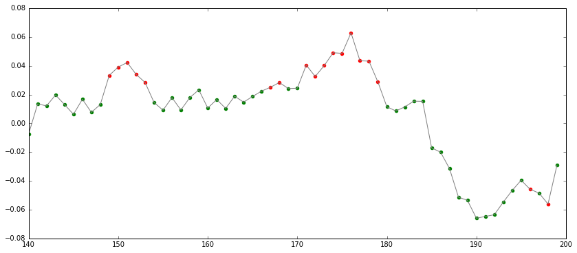

```python
ptmp = Dtmp[-60:]
fig = plt.figure(figsize=(14,6))
plt.plot(ptmp.actual_future_rate_of_return,'gray')
for r,i in enumerate(ptmp.index):
    if tmp_out[r][0] ==1.:
        plt.scatter(i,ptmp.ix[i]['actual_future_rate_of_return'] ,color='g')
    elif tmp_out[r][1] ==1.:
        plt.scatter(i,ptmp.ix[i]['actual_future_rate_of_return'] ,color='r')
plt.xlim(140,200)
plt.show()
```

### 回测，我不太熟悉RiceQuant 回测平台，回测有空再写